# Ayudantía 1: OLS y ATE

**Ayudante: Thomas Buddemberg**

**Mail: tbuddemberg@alumnos.uai.cl**

**Whatsapp: +569 7532 8800**

# Table of Contents

Continuaremos con el mismo ejemplo de la ayudantía anterior sobre el análisis de los resultados de una prueba A/B realizada por un sitio web de comercio electrónico. Pero hoy trabajaremos usando un **estimador muestral** y una **Regresion OLS** con el tratamiento + intercepto para estimar el **ATE** y mostrar que los estimadores son iguales.

**Recordemos nuestro Conjunto de datos**

El conjunto de datos que se utilizará para el análisis consta de 5 columnas:

- *user_id:* ID de usuario único
- *timestamp:* representa cuándo comienza una sesión para un usuario.
- *group:* contiene 2 valores diferentes como control y tratamiento.
- *landing_page:* contiene 2 valores diferentes como `old_page` y `new_page`.
- *converted:* representa el comportamiento del usuario: si un usuario realizó una compra (1) o no (0).

```python
# Utilizamos la data limpia
df = pd.read_csv('ab_data_clean.csv')
df.drop(columns='Unnamed: 0', inplace=True)
df.head()
```

|  | user_id | timestamp | group | landing_page | converted |
| --- | --- | --- | --- | --- | --- |
| 0 | 851104 | 2017-01-21 22:11:48.556739 | control | old_page | 0 |
| 1 | 804228 | 2017-01-12 08:01:45.159739 | control | old_page | 0 |
| 2 | 661590 | 2017-01-11 16:55:06.154213 | treatment | new_page | 0 |
| 3 | 853541 | 2017-01-08 18:28:03.143765 | treatment | new_page | 0 |
| 4 | 864975 | 2017-01-21 01:52:26.210827 | control | old_page | 1 |

- **Vector Objetivo**: El vector o variable objetivo sería `converted`, ya que deseamos saber si la persona compró o no en la página web.
- **Tratamiento**: La variable de tratamiento es `group`, siendo **treatment** los clientes tratados con la nueva página web y **control** los que no son tratados con la nueva página. Simil con la variable `landing_page`, tratados **new_page** y no tratados **old_page**.
- **Posibles Covariables**: No existen covariables.
- **Hipótesis**: La hipótesis que se plantearía sería que existe una diferencia en compras entre los clientes que utilizan la nueva página web y los que usan la antigua.

# Estimador muestral (Diferencia de medias)

```python
df.groupby('group')['converted'].describe().T
```

| group | control | treatment |
| --- | --- | --- |
| count | 145274.000000 | 145310.000000 |
| mean | 0.120386 | 0.118808 |
| std | 0.325414 | 0.323564 |
| min | 0.000000 | 0.000000 |
| 25% | 0.000000 | 0.000000 |
| 50% | 0.000000 | 0.000000 |
| 75% | 0.000000 | 0.000000 |
| max | 1.000000 | 1.000000 |

```
(array([0, 1]), [Text(0, 0, 'control'), Text(1, 0, 'treatment')])
```

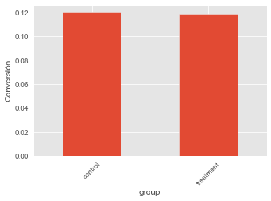

```python
fig, ax1 = plt.subplots(1, 1, figsize=(6,4))

df.groupby('group')['converted'].mean().plot(kind='bar', ax=ax1)
plt.ylabel('Conversión')
plt.xticks(rotation=45)
```

```
(array([0, 1]), [Text(0, 0, '0'), Text(1, 0, '1')])
```

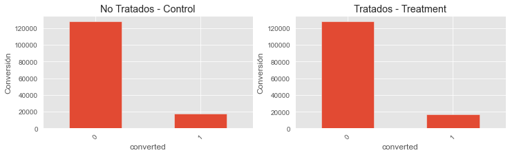

```python
fig, (ax1, ax2) = plt.subplots(1, 2, figsize=(12,3))


plt.subplot(1, 2, 1)
df[df.group == 'control'].groupby('converted').count()['group'].plot(kind='bar', ax=ax1)
plt.title('No Tratados - Control')
plt.ylabel('Conversión')
plt.xticks(rotation=45)

plt.subplot(1, 2, 2)
df[df.group == 'treatment'].groupby('converted').count()['group'].plot(kind='bar', ax=ax2)
plt.title('Tratados - Treatment')
plt.ylabel('Conversión')
plt.xticks(rotation=45)
```

```python
print(f"nps_post:\n{pg.homoscedasticity(data=df, dv='converted', group='group', method='levene')}")
```

```
nps_post:
               W      pval  equal_var
levene  1.718521  0.189885       True
```

```python
t_stat, p_value = ttest_ind(df[df['group']=='control'].converted, df[df['group']=='treatment'].converted)
print("T-statistic value: ", t_stat)
print("P-Value: ", p_value)

if p_value < 0.05:
    print('Se rechaza la hipotesis nula, la diferencia de medias no es cero')
else:
    print('Se acepta la hipotesis nula, la diferencia de medias es cero')

res = stat()
res.ttest(df=df, xfac="group", res="converted", test_type=2, evar=True)
```

```
T-statistic value:  1.3109235634981506
P-Value:  0.18988462498742617
Se acepta la hipotesis nula, la diferencia de medias es cero
```

```python
print(res.summary)
```

```
Two sample t-test with equal variance

------------------  ----------------
Mean diff                0.00157824
t                        1.31092
Std Error                0.00120391
df                  290582
p value (one-tail)       0.0949423
p value (two-tail)       0.189885
Lower 95.0%             -0.000781399
Upper 95.0%              0.00393788
------------------  ----------------

Parameter estimates

Level        Number      Mean    Std Dev    Std Error    Lower 95.0%    Upper 95.0%
---------  --------  --------  ---------  -----------  -------------  -------------
control      145274  0.120386   0.325414  0.000853772       0.118713       0.12206
treatment    145310  0.118808   0.323564  0.000848813       0.117144       0.120472
```

Podemos ver que la diferencia de medias entre tratados y no tratados es de **0.001578**. O sea, prácticamente no existe una diferencia entre los grupos.

# Regresiones

**La regresión se utiliza para evaluar las relaciones que existen entre dos o más atributos de entidades.**

La identificación y medición de las relaciones permite comprender mejor lo que sucede en un lugar, prever el lugar donde es probable que suceda algo o **examinar las causas que hacen que algo suceda en un lugar determinado**.

**Regresion lineal simple:**

$y = \beta_0 + \beta_1*x_{1}$

$y = a + b*x$

$y$ -> Rentabilidad mensual de una empresa

$x_{1}$ -> Cantidad de dinero invertida en marketing

**Regresion lineal múltiple:**

$y = \beta_0 + \beta_1*x_{1} + \beta_2*x_{2} + \beta_3*x_{3} + \beta_4*x_{4} + \beta_5*x_{5}$

[figure not shown]

## Regresión OLS

**Mínimos cuadrados ordinarios (OLS: Ordinary Least Squares) es la técnica de regresión más conocida**.

**OLS Simple**

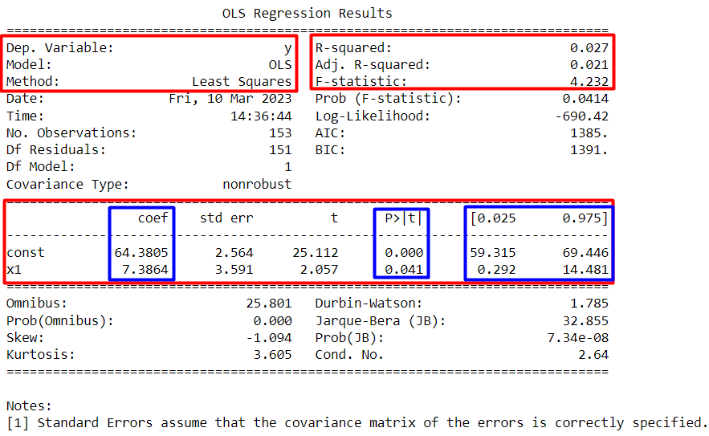

**OLS Múltiple**

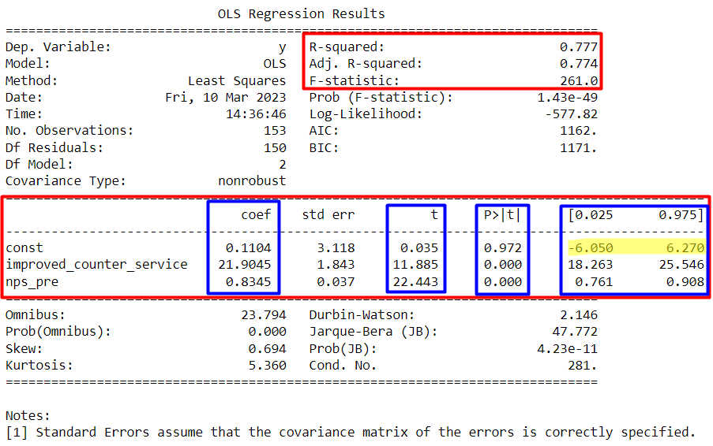

Realizaremos una **Regresión Lineal Simple** donde regresionamos la intervención en el vector objetivo. Reportamos el impacto del coeficiente estimado de la intervención. ¿Es este análogo al estimando anteriormente?

$converted = \beta_{0} + \tau_{1}group + \varepsilon_{i}$

```python
df.head()
```

|  | user_id | timestamp | group | landing_page | converted |
| --- | --- | --- | --- | --- | --- |
| 0 | 851104 | 2017-01-21 22:11:48.556739 | control | old_page | 0 |
| 1 | 804228 | 2017-01-12 08:01:45.159739 | control | old_page | 0 |
| 2 | 661590 | 2017-01-11 16:55:06.154213 | treatment | new_page | 0 |
| 3 | 853541 | 2017-01-08 18:28:03.143765 | treatment | new_page | 0 |
| 4 | 864975 | 2017-01-21 01:52:26.210827 | control | old_page | 1 |

```python
df.group.replace('control', 0, inplace=True)
df.group.replace('treatment', 1, inplace=True)
df.group.head()
```

```
0    0
1    0
2    1
3    1
4    0
Name: group, dtype: int64
```

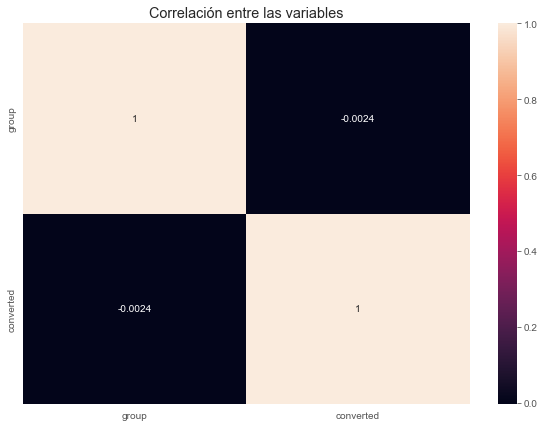

```python
plt.figure(figsize=(10,7))
sns.heatmap(df.drop(columns='user_id').corr(), annot=True) # annot = False: no escribe números en el heatmap
plt.title('Correlación entre las variables')
plt.show()
```

### Entrenamiento del modelo

```python
from sklearn import linear_model

X = df[['group']]
y = df[['converted']]

# Asignamos nuestra variable de entrada X para entrenamiento y las etiquetas Y.
X_train_S = np.array(X)
y_train_S = y.values

# Creamos el objeto de Regresión Linear
regr = linear_model.LinearRegression()

# Entrenamos nuestro modelo
regr.fit(X_train_S, y_train_S)

# Hacemos las predicciones que en definitiva una línea (en este caso, al ser 2D)
y_pred_S = regr.predict(X_train_S)
```

```python
from sklearn.metrics import mean_squared_error, r2_score
print('Coefficients: \n', regr.coef_)
print('Independent term: \n', regr.intercept_)
print('Variance score (R2): %.2f' % r2_score(y_train_S, y_pred_S))
```

```
Coefficients:
 [[-0.00157824]]
Independent term:
 [0.1203863]
Variance score (R2): 0.00
```

$y = a + b*x$

$y = 0.1203863 + -0.00157824*x$

```python
#Parameter estimates

#Level        Number      Mean    Std Dev    Std Error    Lower 95.0%    Upper 95.0%
#---------  --------  --------  ---------  -----------  -------------  -------------
#control      145274  0.120386   0.325414  0.000853772       0.118713       0.12206
#treatment    145310  0.118808   0.323564  0.000848813       0.117144       0.120472
```

```python
import statsmodels.api as sm

X_train_OLS = sm.add_constant(X_train_S, prepend=True)
modelo_OLS0 = sm.OLS(endog=y_train_S, exog=X_train_OLS,)
modelo_OLS0 = modelo_OLS0.fit()
```

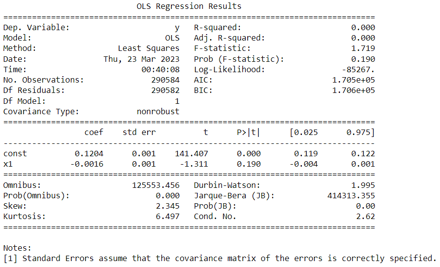

## Regresión con nuevos datos

```python
df = pd.read_csv('nps_experiment.csv')
df.drop(columns='Unnamed: 0', inplace=True)
df[['nps_pre', 'nps_post', 'airports', 'improved_counter_service', 'pair_id']]
df.head()
```

|  | nps_post | nps_pre | airports | improved_counter_service | pair_id |
| --- | --- | --- | --- | --- | --- |
| 0 | 6.041131 | 4.504505 | Alta | 1 | 1 |
| 1 | 33.804627 | 6.936937 | Alta | 1 | 2 |
| 2 | 58.483290 | 8.738739 | Alta | 1 | 3 |
| 3 | 0.000000 | 0.000000 | Alta | 1 | 4 |
| 4 | 42.802057 | 5.855856 | Alta | 1 | 5 |

[output not shown]

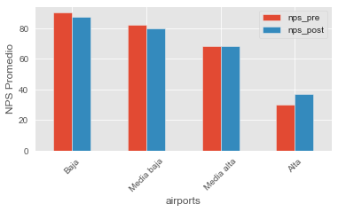

```python
fig, ax1 = plt.subplots(1, 1, figsize=(6,3))

df.groupby('airports')['nps_pre', 'nps_post'].mean().sort_values('nps_post',ascending=False).plot(kind='bar', ax=ax1)
plt.ylabel('NPS Promedio')
plt.xticks(rotation=45)
```

[output not shown]

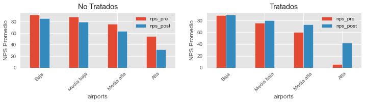

```python
fig, (ax1, ax2) = plt.subplots(1, 2, figsize=(12,2))
plt.subplot(1, 2, 1)
df[df.improved_counter_service == 0].groupby('airports')['nps_pre', 'nps_post'].mean().sort_values('nps_post',ascending=False).plot(kind='bar', ax=ax1)
plt.title('No Tratados')
plt.ylabel('NPS Promedio')
plt.xticks(rotation=45)
plt.subplot(1, 2, 2)
df[df.improved_counter_service == 1].groupby('airports')['nps_pre', 'nps_post'].mean().sort_values('nps_post',ascending=False).plot(kind='bar', ax=ax2)
plt.title('Tratados')
plt.ylabel('NPS Promedio')
plt.xticks(rotation=45)
```

```python
print(f"\nDescripción variables nps NO TRATADOS:\n\n{df[df['improved_counter_service'] == 0][['nps_pre', 'nps_post']].describe()}\n")

print(f"\nDescripción variables nps TRATADOS:\n\n{df[df['improved_counter_service'] == 1][['nps_pre', 'nps_post']].describe()}\n")
```

```
Descripción variables nps NO TRATADOS:

         nps_pre   nps_post
count  96.000000  96.000000
mean   77.045796  64.422665
std    16.579405  23.654422
min    34.414414   3.598972
25%    65.855856  48.457584
50%    81.486486  70.758355
75%    91.373874  84.865039
max    98.378378  94.858612


Descripción variables nps TRATADOS:

          nps_pre    nps_post
count   96.000000   96.000000
mean    58.043356   71.694248
std     30.620121   21.477839
min      0.000000    0.000000
25%     47.882883   62.050129
50%     65.450450   77.956298
75%     82.882883   87.467866
max    100.000000  100.000000
```

```python
print(f"nps_post:\n{pg.homoscedasticity(data=df, dv='nps_post', group='improved_counter_service', method='levene')}")
```

```
nps_post:
               W      pval  equal_var
levene  1.449859  0.230048       True
```

Del test de homocedasticidad de Levene podemos concluir que las varianzas son iguales en `nps_post`, por lo que podemos concluir que entre tratados y no tratados el `nps_post` es homocedástico (varianzas iguales).

Como las varianzas son iguales utilizamos **Prueba t de Student** para medir la diferencia de medias (**Prueba t de Welch** si varianzas no son similiares):

```python
t_stat, p_value = ttest_ind(df[df['improved_counter_service']==0].nps_post, df[df['improved_counter_service']==1].nps_post)
print("T-statistic value: ", t_stat)
print("P-Value: ", p_value)

if p_value < 0.05:
    print('Se rechaza la hipotesis nula, la diferencia de medias no es cero')
else:
    print('Se acepta la hipotesis nula, la diferencia de medias es cero')
```

```
T-statistic value:  -2.2299136152470096
P-Value:  0.02692384979774391
Se rechaza la hipotesis nula, la diferencia de medias no es cero
```

```python
res = stat()
res.ttest(df=df, xfac="improved_counter_service", res="nps_post", test_type=2, evar=True)
print(res.summary)
```

```
Two sample t-test with equal variance

------------------  -----------
Mean diff            -7.27158
t                    -2.22991
Std Error             3.26093
df                  190
p value (one-tail)    0.0134619
p value (two-tail)    0.0269238
Lower 95.0%         -13.7039
Upper 95.0%          -0.839315
------------------  -----------

Parameter estimates

  Level    Number     Mean    Std Dev    Std Error    Lower 95.0%    Upper 95.0%
-------  --------  -------  ---------  -----------  -------------  -------------
      0        96  64.4227    23.6544      2.41422        59.6298        69.2155
      1        96  71.6942    21.4778      2.19207        67.3424        76.0461
```

### Regresión

Lo primero será realizar una regresión lineal simple donde regresionamos la intervención en el vector objetivo. Reportamos el impacto del coeficiente estimado de la intervención. ¿Es este análogo al estimando anteriormente (**7.27**)?

$NPS\_Post = \beta_{0} + \tau_{1}Intervención + \varepsilon_{i}$

```python
# Correlación lineal entre las dos variables
#--------------------------------------------------------------------------------------
corr_test = pearsonr(x = df['improved_counter_service'], y =  df['nps_post'])
print("Coeficiente de correlación de Pearson: ", corr_test[0])
print("P-value: ", corr_test[1])
```

```
Coeficiente de correlación de Pearson:  0.15969868593924297
P-value:  0.02692384979774403
```

```python
# División de los datos en train y test
#--------------------------------------------------------------------------------------
X = df[['improved_counter_service']]
y = df['nps_post']

X_train, X_test, y_train, y_test = train_test_split(X.values.reshape(-1,1), y.values.reshape(-1,1), train_size = 0.8,
                                        random_state = 1234, shuffle = True)
```

[figure not shown]

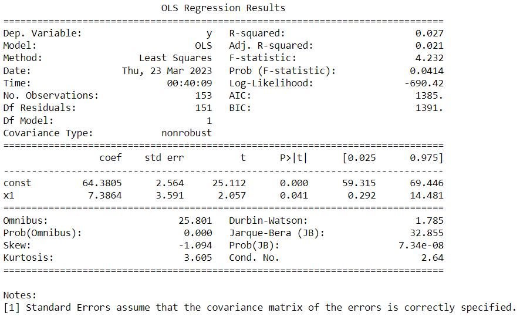

Podemos ver que con la regresión lineal conseguimos un efecto de tratamiento muy similiar al de diferencias de medias (estimador muestral)

Estimador: $7.27$

Regresión: $7.38$